# Welcome to Colaboratory!

Colaboratory is a free Jupyter notebook environment that requires no setup and runs entirely in the cloud.

With Colaboratory you can write and execute code, save and share your analyses, and access powerful computing resources, all for free from your browser.

```python
#@title Introducing Colaboratory { display-mode: "form" }
#@markdown This 3-minute video gives an overview of the key features of Colaboratory:
from IPython.display import YouTubeVideo
YouTubeVideo('inN8seMm7UI', width=600, height=400)
```

[video not shown]

## Getting Started

The document you are reading is a [Jupyter notebook](https://jupyter.org/), hosted in Colaboratory. It is not a static page, but an interactive environment that lets you write and execute code in Python and other languages.

For example, here is a **code cell** with a short Python script that computes a value, stores it in a variable, and prints the result:

```python
seconds_in_a_day = 24 * 60 * 60
seconds_in_a_day
```

```
86400
```

To execute the code in the above cell, select it with a click and then either press the play button to the left of the code, or use the keyboard shortcut "Command/Ctrl+Enter".

All cells modify the same global state, so variables that you define by executing a cell can be used in other cells:

```python
seconds_in_a_week = 7 * seconds_in_a_day
seconds_in_a_week
```

```
604800
```

For more information about working with Colaboratory notebooks, see Overview of Colaboratory.

## More Resources

Learn how to make the most of Python, Jupyter, Colaboratory, and related tools with these resources:

### Working with Notebooks in Colaboratory

- Overview of Colaboratory
- Guide to Markdown
- Importing libraries and installing dependencies
- [Saving and loading notebooks in GitHub](https://colab.research.google.com/github/googlecolab/colabtools/blob/master/notebooks/colab-github-demo.ipynb)
- Interactive forms
- Interactive widgets
- TensorFlow 2 in Colab

### Working with Data

- Loading data: Drive, Sheets, and Google Cloud Storage
- Charts: visualizing data
- Getting started with BigQuery

### Machine Learning Crash Course

These are a few of the notebooks from Google's online Machine Learning course. See the [full course website](https://developers.google.com/machine-learning/crash-course/) for more.

- Intro to Pandas
- Tensorflow concepts
- First steps with TensorFlow
- Intro to neural nets
- Intro to sparse data and embeddings

### Using Accelerated Hardware

- TensorFlow with GPUs
- TensorFlow with TPUs

## Machine Learning Examples: Seedbank

To see end-to-end examples of the interactive machine learning analyses that Colaboratory makes possible, check out the [Seedbank](https://research.google.com/seedbank/) project.

A few featured examples:

- [Neural Style Transfer](https://research.google.com/seedbank/seed/neural_style_transfer_with_tfkeras): Use deep learning to transfer style between images.
- [EZ NSynth](https://research.google.com/seedbank/seed/ez_nsynth): Synthesize audio with WaveNet auto-encoders.
- [Fashion MNIST with Keras and TPUs](https://research.google.com/seedbank/seed/fashion_mnist_with_keras_and_tpus): Classify fashion-related images with deep learning.
- [DeepDream](https://research.google.com/seedbank/seed/deepdream): Produce DeepDream images from your own photos.
- [Convolutional VAE](https://research.google.com/seedbank/seed/convolutional_vae): Create a generative model of handwritten digits.

```python
import numpy as np
import pandas as pd
import sklearn
from sklearn import preprocessing

import seaborn as sns
from sklearn.model_selection import train_test_split
from sklearn import metrics
from sklearn.metrics import roc_curve,auc,recall_score,precision_score,accuracy_score,f1_score
from sklearn.metrics import confusion_matrix,average_precision_score,recall_score
import matplotlib.pyplot as plt
%matplotlib inline
```

```python
from IPython.core.interactiveshell import InteractiveShell
InteractiveShell.ast_node_interactivity = "all"
```

```python
pwd
```

```
'/content'
```

```python
#df=pd.read_csv("C:\Users\mba-17\Desktop\ASSIGNMENT_LINEAR_REGRESSION\churn.csv")
df=pd.read_csv("files.csv")
df.shape
```

```
(7043, 21)
```

```python
type(df)
```

```
pandas.core.frame.DataFrame
```

```python
df.head()
```

|  | customerID | gender | SeniorCitizen | Partner | Dependents | tenure | PhoneService | MultipleLines | InternetService | OnlineSecurity | OnlineBackup | DeviceProtection | TechSupport | StreamingTV | StreamingMovies | Contract | PaperlessBilling | PaymentMethod | MonthlyCharges | TotalCharges | Churn |
| --- | --- | --- | --- | --- | --- | --- | --- | --- | --- | --- | --- | --- | --- | --- | --- | --- | --- | --- | --- | --- | --- |
| 0 | 7590-VHVEG | Female | 0 | Yes | No | 1 | No | No phone service | DSL | No | Yes | No | No | No | No | Month-to-month | Yes | Electronic check | 29.85 | 29.85 | No |
| 1 | 5575-GNVDE | Male | 0 | No | No | 34 | Yes | No | DSL | Yes | No | Yes | No | No | No | One year | No | Mailed check | 56.95 | 1889.5 | No |
| 2 | 3668-QPYBK | Male | 0 | No | No | 2 | Yes | No | DSL | Yes | Yes | No | No | No | No | Month-to-month | Yes | Mailed check | 53.85 | 108.15 | Yes |
| 3 | 7795-CFOCW | Male | 0 | No | No | 45 | No | No phone service | DSL | Yes | No | Yes | Yes | No | No | One year | No | Bank transfer (automatic) | 42.30 | 1840.75 | No |
| 4 | 9237-HQITU | Female | 0 | No | No | 2 | Yes | No | Fiber optic | No | No | No | No | No | No | Month-to-month | Yes | Electronic check | 70.70 | 151.65 | Yes |

```python
df.tail()
```

|  | customerID | gender | SeniorCitizen | Partner | Dependents | tenure | PhoneService | MultipleLines | InternetService | OnlineSecurity | OnlineBackup | DeviceProtection | TechSupport | StreamingTV | StreamingMovies | Contract | PaperlessBilling | PaymentMethod | MonthlyCharges | TotalCharges | Churn |
| --- | --- | --- | --- | --- | --- | --- | --- | --- | --- | --- | --- | --- | --- | --- | --- | --- | --- | --- | --- | --- | --- |
| 7038 | 6840-RESVB | Male | 0 | Yes | Yes | 24 | Yes | Yes | DSL | Yes | No | Yes | Yes | Yes | Yes | One year | Yes | Mailed check | 84.80 | 1990.5 | No |
| 7039 | 2234-XADUH | Female | 0 | Yes | Yes | 72 | Yes | Yes | Fiber optic | No | Yes | Yes | No | Yes | Yes | One year | Yes | Credit card (automatic) | 103.20 | 7362.9 | No |
| 7040 | 4801-JZAZL | Female | 0 | Yes | Yes | 11 | No | No phone service | DSL | Yes | No | No | No | No | No | Month-to-month | Yes | Electronic check | 29.60 | 346.45 | No |
| 7041 | 8361-LTMKD | Male | 1 | Yes | No | 4 | Yes | Yes | Fiber optic | No | No | No | No | No | No | Month-to-month | Yes | Mailed check | 74.40 | 306.6 | Yes |
| 7042 | 3186-AJIEK | Male | 0 | No | No | 66 | Yes | No | Fiber optic | Yes | No | Yes | Yes | Yes | Yes | Two year | Yes | Bank transfer (automatic) | 105.65 | 6844.5 | No |

```python
df.size
```

```
147903
```

```python
df.info()
```

```
<class 'pandas.core.frame.DataFrame'>
RangeIndex: 7043 entries, 0 to 7042
Data columns (total 21 columns):
customerID          7043 non-null object
gender              7043 non-null object
SeniorCitizen       7043 non-null int64
Partner             7043 non-null object
Dependents          7043 non-null object
tenure              7043 non-null int64
PhoneService        7043 non-null object
MultipleLines       7043 non-null object
InternetService     7043 non-null object
OnlineSecurity      7043 non-null object
OnlineBackup        7043 non-null object
DeviceProtection    7043 non-null object
TechSupport         7043 non-null object
StreamingTV         7043 non-null object
StreamingMovies     7043 non-null object
Contract            7043 non-null object
PaperlessBilling    7043 non-null object
PaymentMethod       7043 non-null object
MonthlyCharges      7043 non-null float64
TotalCharges        7043 non-null object
Churn               7043 non-null object
dtypes: float64(1), int64(2), object(18)
memory usage: 1.1+ MB
```

```python
pd.isnull(df).any()
```

```
customerID          False
gender              False
SeniorCitizen       False
Partner             False
Dependents          False
tenure              False
PhoneService        False
MultipleLines       False
InternetService     False
OnlineSecurity      False
OnlineBackup        False
DeviceProtection    False
TechSupport         False
StreamingTV         False
StreamingMovies     False
Contract            False
PaperlessBilling    False
PaymentMethod       False
MonthlyCharges      False
TotalCharges        False
Churn               False
dtype: bool
```

```python
pd.isnull(df).sum()
```

```
customerID          0
gender              0
SeniorCitizen       0
Partner             0
Dependents          0
tenure              0
PhoneService        0
MultipleLines       0
InternetService     0
OnlineSecurity      0
OnlineBackup        0
DeviceProtection    0
TechSupport         0
StreamingTV         0
StreamingMovies     0
Contract            0
PaperlessBilling    0
PaymentMethod       0
MonthlyCharges      0
TotalCharges        0
Churn               0
dtype: int64
```

```python
df.describe()
```

|  | SeniorCitizen | tenure | MonthlyCharges |
| --- | --- | --- | --- |
| count | 7043.000000 | 7043.000000 | 7043.000000 |
| mean | 0.162147 | 32.371149 | 64.761692 |
| std | 0.368612 | 24.559481 | 30.090047 |
| min | 0.000000 | 0.000000 | 18.250000 |
| 25% | 0.000000 | 9.000000 | 35.500000 |
| 50% | 0.000000 | 29.000000 | 70.350000 |
| 75% | 0.000000 | 55.000000 | 89.850000 |
| max | 1.000000 | 72.000000 | 118.750000 |

```python
#DUMMY CODING USING THE LOOP STRUCTURE
for col in df.columns:
  if df[col].dtype=='object':
    df[col]=pd.Categorical(df[col]).codes
    df.head(5)
```

```python
df
```

|  | customerID | gender | SeniorCitizen | Partner | Dependents | tenure | PhoneService | MultipleLines | InternetService | OnlineSecurity | OnlineBackup | DeviceProtection | TechSupport | StreamingTV | StreamingMovies | Contract | PaperlessBilling | PaymentMethod | MonthlyCharges | TotalCharges | Churn |
| --- | --- | --- | --- | --- | --- | --- | --- | --- | --- | --- | --- | --- | --- | --- | --- | --- | --- | --- | --- | --- | --- |
| 0 | 5375 | 0 | 0 | 1 | 0 | 1 | 0 | 1 | 0 | 0 | 2 | 0 | 0 | 0 | 0 | 0 | 1 | 2 | 29.85 | 2505 | 0 |
| 1 | 3962 | 1 | 0 | 0 | 0 | 34 | 1 | 0 | 0 | 2 | 0 | 2 | 0 | 0 | 0 | 1 | 0 | 3 | 56.95 | 1466 | 0 |
| 2 | 2564 | 1 | 0 | 0 | 0 | 2 | 1 | 0 | 0 | 2 | 2 | 0 | 0 | 0 | 0 | 0 | 1 | 3 | 53.85 | 157 | 1 |
| 3 | 5535 | 1 | 0 | 0 | 0 | 45 | 0 | 1 | 0 | 2 | 0 | 2 | 2 | 0 | 0 | 1 | 0 | 0 | 42.30 | 1400 | 0 |
| 4 | 6511 | 0 | 0 | 0 | 0 | 2 | 1 | 0 | 1 | 0 | 0 | 0 | 0 | 0 | 0 | 0 | 1 | 2 | 70.70 | 925 | 1 |
| ... | ... | ... | ... | ... | ... | ... | ... | ... | ... | ... | ... | ... | ... | ... | ... | ... | ... | ... | ... | ... | ... |
| 7038 | 4853 | 1 | 0 | 1 | 1 | 24 | 1 | 2 | 0 | 2 | 0 | 2 | 2 | 2 | 2 | 1 | 1 | 3 | 84.80 | 1597 | 0 |
| 7039 | 1525 | 0 | 0 | 1 | 1 | 72 | 1 | 2 | 1 | 0 | 2 | 2 | 0 | 2 | 2 | 1 | 1 | 1 | 103.20 | 5698 | 0 |
| 7040 | 3367 | 0 | 0 | 1 | 1 | 11 | 0 | 1 | 0 | 2 | 0 | 0 | 0 | 0 | 0 | 0 | 1 | 2 | 29.60 | 2994 | 0 |
| 7041 | 5934 | 1 | 1 | 1 | 0 | 4 | 1 | 2 | 1 | 0 | 0 | 0 | 0 | 0 | 0 | 0 | 1 | 3 | 74.40 | 2660 | 1 |
| 7042 | 2226 | 1 | 0 | 0 | 0 | 66 | 1 | 0 | 1 | 2 | 0 | 2 | 2 | 2 | 2 | 2 | 1 | 0 | 105.65 | 5407 | 0 |

7043 rows × 21 columns

```python
df.drop(['customerID','TotalCharges'],axis=1)
```

|  | gender | SeniorCitizen | Partner | Dependents | tenure | PhoneService | MultipleLines | InternetService | OnlineSecurity | OnlineBackup | DeviceProtection | TechSupport | StreamingTV | StreamingMovies | Contract | PaperlessBilling | PaymentMethod | MonthlyCharges | Churn |
| --- | --- | --- | --- | --- | --- | --- | --- | --- | --- | --- | --- | --- | --- | --- | --- | --- | --- | --- | --- |
| 0 | 0 | 0 | 1 | 0 | 1 | 0 | 1 | 0 | 0 | 2 | 0 | 0 | 0 | 0 | 0 | 1 | 2 | 29.85 | 0 |
| 1 | 1 | 0 | 0 | 0 | 34 | 1 | 0 | 0 | 2 | 0 | 2 | 0 | 0 | 0 | 1 | 0 | 3 | 56.95 | 0 |
| 2 | 1 | 0 | 0 | 0 | 2 | 1 | 0 | 0 | 2 | 2 | 0 | 0 | 0 | 0 | 0 | 1 | 3 | 53.85 | 1 |
| 3 | 1 | 0 | 0 | 0 | 45 | 0 | 1 | 0 | 2 | 0 | 2 | 2 | 0 | 0 | 1 | 0 | 0 | 42.30 | 0 |
| 4 | 0 | 0 | 0 | 0 | 2 | 1 | 0 | 1 | 0 | 0 | 0 | 0 | 0 | 0 | 0 | 1 | 2 | 70.70 | 1 |
| ... | ... | ... | ... | ... | ... | ... | ... | ... | ... | ... | ... | ... | ... | ... | ... | ... | ... | ... | ... |
| 7038 | 1 | 0 | 1 | 1 | 24 | 1 | 2 | 0 | 2 | 0 | 2 | 2 | 2 | 2 | 1 | 1 | 3 | 84.80 | 0 |
| 7039 | 0 | 0 | 1 | 1 | 72 | 1 | 2 | 1 | 0 | 2 | 2 | 0 | 2 | 2 | 1 | 1 | 1 | 103.20 | 0 |
| 7040 | 0 | 0 | 1 | 1 | 11 | 0 | 1 | 0 | 2 | 0 | 0 | 0 | 0 | 0 | 0 | 1 | 2 | 29.60 | 0 |
| 7041 | 1 | 1 | 1 | 0 | 4 | 1 | 2 | 1 | 0 | 0 | 0 | 0 | 0 | 0 | 0 | 1 | 3 | 74.40 | 1 |
| 7042 | 1 | 0 | 0 | 0 | 66 | 1 | 0 | 1 | 2 | 0 | 2 | 2 | 2 | 2 | 2 | 1 | 0 | 105.65 | 0 |

7043 rows × 19 columns

```python
x=df.drop(['customerID','TotalCharges','Churn'],axis=1)
x.head()
```

|  | gender | SeniorCitizen | Partner | Dependents | tenure | PhoneService | MultipleLines | InternetService | OnlineSecurity | OnlineBackup | DeviceProtection | TechSupport | StreamingTV | StreamingMovies | Contract | PaperlessBilling | PaymentMethod | MonthlyCharges |
| --- | --- | --- | --- | --- | --- | --- | --- | --- | --- | --- | --- | --- | --- | --- | --- | --- | --- | --- |
| 0 | 0 | 0 | 1 | 0 | 1 | 0 | 1 | 0 | 0 | 2 | 0 | 0 | 0 | 0 | 0 | 1 | 2 | 29.85 |
| 1 | 1 | 0 | 0 | 0 | 34 | 1 | 0 | 0 | 2 | 0 | 2 | 0 | 0 | 0 | 1 | 0 | 3 | 56.95 |
| 2 | 1 | 0 | 0 | 0 | 2 | 1 | 0 | 0 | 2 | 2 | 0 | 0 | 0 | 0 | 0 | 1 | 3 | 53.85 |
| 3 | 1 | 0 | 0 | 0 | 45 | 0 | 1 | 0 | 2 | 0 | 2 | 2 | 0 | 0 | 1 | 0 | 0 | 42.30 |
| 4 | 0 | 0 | 0 | 0 | 2 | 1 | 0 | 1 | 0 | 0 | 0 | 0 | 0 | 0 | 0 | 1 | 2 | 70.70 |

```python
y=df['Churn']
y.head()
```

```
0    0
1    0
2    1
3    0
4    1
Name: Churn, dtype: int8
```

```python
#create test and train data 75% and 25% split
train_x,test_x,train_y,test_y=train_test_split(x,y,test_size=0.25,random_state=1)
train_x.shape
test_x.shape
train_x.shape
train_y.shape
```

```
(5282, 18)
```

```
(1761, 18)
```

```
(5282, 18)
```

```
(5282,)
```

```python
#BUILD A LOGISTIC REGRESSION MODEL
from sklearn.linear_model import LogisticRegression
log=LogisticRegression()
```

```python
log.fit(train_x,train_y)
```

```
LogisticRegression(C=1.0, class_weight=None, dual=False, fit_intercept=True,
                   intercept_scaling=1, l1_ratio=None, max_iter=100,
                   multi_class='auto', n_jobs=None, penalty='l2',
                   random_state=None, solver='lbfgs', tol=0.0001, verbose=0,
                   warm_start=False)
```

```python
log.coef_
```

```
array([[-0.01602902,  0.2379536 ,  0.06960434, -0.11504248, -0.03594874,
        -0.92480377,  0.08789565,  0.24879735, -0.25475313, -0.12502628,
        -0.09883819, -0.24375483,  0.00144582,  0.03585129, -0.67122262,
         0.31543019,  0.03562094,  0.02831369]])
```

```python
#FIND OUT KEY PREDICTOR OF CHURN
coeff=pd.concat([pd.DataFrame(x.columns),pd.DataFrame(np.transpose(log.coef_))],axis=1)
```

```python
coeff.columns=("variables","coeff")
coeff.sort_values("variables",ascending=True)
```

|  | variables | coeff |
| --- | --- | --- |
| 14 | Contract | -0.671223 |
| 3 | Dependents | -0.115042 |
| 10 | DeviceProtection | -0.098838 |
| 7 | InternetService | 0.248797 |
| 17 | MonthlyCharges | 0.028314 |
| 6 | MultipleLines | 0.087896 |
| 9 | OnlineBackup | -0.125026 |
| 8 | OnlineSecurity | -0.254753 |
| 15 | PaperlessBilling | 0.315430 |
| 2 | Partner | 0.069604 |
| 16 | PaymentMethod | 0.035621 |
| 5 | PhoneService | -0.924804 |
| 1 | SeniorCitizen | 0.237954 |
| 13 | StreamingMovies | 0.035851 |
| 12 | StreamingTV | 0.001446 |
| 11 | TechSupport | -0.243755 |
| 0 | gender | -0.016029 |
| 4 | tenure | -0.035949 |

```python
#GENERATE MODEL DIAGNOSTICS
classes=log.predict(test_x)
print(classes.size)
```

```
1761
```

```python
print("positive cases in test data:",test_y[test_y==1].shape[0])
print("Negative cases in Test Data:",test_y[test_y==0].shape[0])
```

```
positive cases in test data: 434
Negative cases in Test Data: 1327
```

```python
#PRECISION AND RECALL
print("ACCUIRACY SCORE")
print(metrics.accuracy_score(test_y,classes))
```

```
ACCUIRACY SCORE
0.8063600227143668
```

```python
#PRECISION RECALL MATRIX
print("precision/recall Metrics")
print(metrics.classification_report(test_y,classes))
```

```
precision/recall Metrics
              precision    recall  f1-score   support

           0       0.86      0.89      0.87      1327
           1       0.62      0.56      0.59       434

    accuracy                           0.81      1761
   macro avg       0.74      0.72      0.73      1761
weighted avg       0.80      0.81      0.80      1761
```

```python
#AUC
print("AUC")
auc=metrics.roc_auc_score(test_y,classes)
auc
```

```
AUC
```

```
0.7242107383342767
```

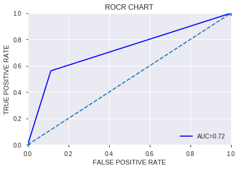

```python
#ROC CHART
fpr,tpr,th=roc_curve(test_y,classes)
roc_auc=metrics.auc(fpr,tpr)
import matplotlib.pyplot as plt
plt.title("ROCR CHART")
plt.plot(fpr,tpr,'b',label="AUC=%0.2F"%roc_auc)
plt.legend(loc="lower right")
plt.plot([0,1],[0,1],"o--")
plt.xlim([0,1])
plt.ylim([0,1])
plt.ylabel("TRUE POSITIVE RATE")
plt.xlabel("FALSE POSITIVE RATE")
plt.show();
```

```
CONFUSION MATRIX
```

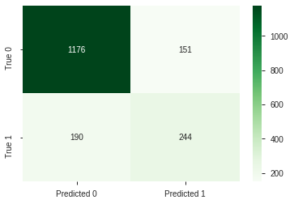

```python
#CONFUSION MATRIX
print("CONFUSION MATRIX")
cf=metrics.confusion_matrix(test_y,classes)
lbl1=["Predicted 0","Predicted 1"]
lbl2=["True 0","True 1"]
sns.heatmap(cf,annot=True,cmap="Greens",fmt="d",xticklabels=lbl1,yticklabels=lbl2)
plt.show()
```

Overview

Dataset info

| Number of variables | 21 |
| --- | --- |
| Number of observations | 7043 |
| Total Missing (%) | 0.0% |
| Total size in memory | 1.1 MiB |
| Average record size in memory | 168.0 B |

Variables types

| Numeric | 2 |
| --- | --- |
| Categorical | 17 |
| Boolean | 1 |
| Date | 0 |
| Text (Unique) | 1 |
| Rejected | 0 |
| Unsupported | 0 |

Warnings

- `TotalCharges` has a high cardinality: 6531 distinct values Warning

Variables

customerID  
Categorical, Unique

| First 3 values |
| --- |
| 2195-ZRVAX |
| 9950-MTGYX |
| 2858-MOFSQ |

| Last 3 values |
| --- |
| 4119-ZYPZY |
| 8984-EYLLL |
| 6416-TVAIH |

Toggle details

First 10 values

| Value | Count | Frequency (%) |  |
| --- | --- | --- | --- |
| 0002-ORFBO | 1 | 0.0% |  |
| 0003-MKNFE | 1 | 0.0% |  |
| 0004-TLHLJ | 1 | 0.0% |  |
| 0011-IGKFF | 1 | 0.0% |  |
| 0013-EXCHZ | 1 | 0.0% |  |

Last 10 values

| Value | Count | Frequency (%) |  |
| --- | --- | --- | --- |
| 9987-LUTYD | 1 | 0.0% |  |
| 9992-RRAMN | 1 | 0.0% |  |
| 9992-UJOEL | 1 | 0.0% |  |
| 9993-LHIEB | 1 | 0.0% |  |
| 9995-HOTOH | 1 | 0.0% |  |

gender  
Categorical

| Distinct count | 2 |
| --- | --- |
| Unique (%) | 0.0% |
| Missing (%) | 0.0% |
| Missing (n) | 0 |

| Male | 3555 |
| --- | --- |
| Female | 3488 |

Toggle details

| Value | Count | Frequency (%) |  |
| --- | --- | --- | --- |
| Male | 3555 | 50.5% |  |
| Female | 3488 | 49.5% |  |

SeniorCitizen  
Boolean

| Distinct count | 2 |
| --- | --- |
| Unique (%) | 0.0% |
| Missing (%) | 0.0% |
| Missing (n) | 0 |

| Mean | 0.16215 |
| --- | --- |

| 0 | 5901 |
| --- | --- |
| 1 | 1142 |

Toggle details

| Value | Count | Frequency (%) |  |
| --- | --- | --- | --- |
| 0 | 5901 | 83.8% |  |
| 1 | 1142 | 16.2% |  |

Partner  
Categorical

| Distinct count | 2 |
| --- | --- |
| Unique (%) | 0.0% |
| Missing (%) | 0.0% |
| Missing (n) | 0 |

| No | 3641 |
| --- | --- |
| Yes | 3402 |

Toggle details

| Value | Count | Frequency (%) |  |
| --- | --- | --- | --- |
| No | 3641 | 51.7% |  |
| Yes | 3402 | 48.3% |  |

Dependents  
Categorical

| Distinct count | 2 |
| --- | --- |
| Unique (%) | 0.0% |
| Missing (%) | 0.0% |
| Missing (n) | 0 |

| No | 4933 |
| --- | --- |
| Yes | 2110 |

Toggle details

| Value | Count | Frequency (%) |  |
| --- | --- | --- | --- |
| No | 4933 | 70.0% |  |
| Yes | 2110 | 30.0% |  |

tenure  
Numeric

| Distinct count | 73 |
| --- | --- |
| Unique (%) | 1.0% |
| Missing (%) | 0.0% |
| Missing (n) | 0 |
| Infinite (%) | 0.0% |
| Infinite (n) | 0 |

| Mean | 32.371 |
| --- | --- |
| Minimum | 0 |
| Maximum | 72 |
| Zeros (%) | 0.2% |

Toggle details

**Statistics**

Quantile statistics

| Minimum | 0 |
| --- | --- |
| 5-th percentile | 1 |
| Q1 | 9 |
| Median | 29 |
| Q3 | 55 |
| 95-th percentile | 72 |
| Maximum | 72 |
| Range | 72 |
| Interquartile range | 46 |

Descriptive statistics

| Standard deviation | 24.559 |
| --- | --- |
| Coef of variation | 0.75868 |
| Kurtosis | -1.3874 |
| Mean | 32.371 |
| MAD | 21.873 |
| Skewness | 0.23954 |
| Sum | 227990 |
| Variance | 603.17 |
| Memory size | 55.1 KiB |

**Histogram**

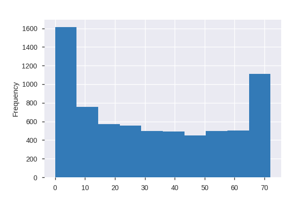

**Common Values**

| Value | Count | Frequency (%) |  |
| --- | --- | --- | --- |
| 1 | 613 | 8.7% |  |
| 72 | 362 | 5.1% |  |
| 2 | 238 | 3.4% |  |
| 3 | 200 | 2.8% |  |
| 4 | 176 | 2.5% |  |
| 71 | 170 | 2.4% |  |
| 5 | 133 | 1.9% |  |
| 7 | 131 | 1.9% |  |
| 8 | 123 | 1.7% |  |
| 70 | 119 | 1.7% |  |
| Other values (63) | 4778 | 67.8% |  |

**Extreme Values**

Minimum 5 values

| Value | Count | Frequency (%) |  |
| --- | --- | --- | --- |
| 0 | 11 | 0.2% |  |
| 1 | 613 | 8.7% |  |
| 2 | 238 | 3.4% |  |
| 3 | 200 | 2.8% |  |
| 4 | 176 | 2.5% |  |

Maximum 5 values

| Value | Count | Frequency (%) |  |
| --- | --- | --- | --- |
| 68 | 100 | 1.4% |  |
| 69 | 95 | 1.3% |  |
| 70 | 119 | 1.7% |  |
| 71 | 170 | 2.4% |  |
| 72 | 362 | 5.1% |  |

PhoneService  
Categorical

| Distinct count | 2 |
| --- | --- |
| Unique (%) | 0.0% |
| Missing (%) | 0.0% |
| Missing (n) | 0 |

| Yes | 6361 |
| --- | --- |
| No | 682 |

Toggle details

| Value | Count | Frequency (%) |  |
| --- | --- | --- | --- |
| Yes | 6361 | 90.3% |  |
| No | 682 | 9.7% |  |

MultipleLines  
Categorical

| Distinct count | 3 |
| --- | --- |
| Unique (%) | 0.0% |
| Missing (%) | 0.0% |
| Missing (n) | 0 |

| No | 3390 |
| --- | --- |
| Yes | 2971 |
| No phone service | 682 |

Toggle details

| Value | Count | Frequency (%) |  |
| --- | --- | --- | --- |
| No | 3390 | 48.1% |  |
| Yes | 2971 | 42.2% |  |
| No phone service | 682 | 9.7% |  |

InternetService  
Categorical

| Distinct count | 3 |
| --- | --- |
| Unique (%) | 0.0% |
| Missing (%) | 0.0% |
| Missing (n) | 0 |

| Fiber optic | 3096 |
| --- | --- |
| DSL | 2421 |
| No | 1526 |

Toggle details

| Value | Count | Frequency (%) |  |
| --- | --- | --- | --- |
| Fiber optic | 3096 | 44.0% |  |
| DSL | 2421 | 34.4% |  |
| No | 1526 | 21.7% |  |

OnlineSecurity  
Categorical

| Distinct count | 3 |
| --- | --- |
| Unique (%) | 0.0% |
| Missing (%) | 0.0% |
| Missing (n) | 0 |

| No | 3498 |
| --- | --- |
| Yes | 2019 |
| No internet service | 1526 |

Toggle details

| Value | Count | Frequency (%) |  |
| --- | --- | --- | --- |
| No | 3498 | 49.7% |  |
| Yes | 2019 | 28.7% |  |
| No internet service | 1526 | 21.7% |  |

OnlineBackup  
Categorical

| Distinct count | 3 |
| --- | --- |
| Unique (%) | 0.0% |
| Missing (%) | 0.0% |
| Missing (n) | 0 |

| No | 3088 |
| --- | --- |
| Yes | 2429 |
| No internet service | 1526 |

Toggle details

| Value | Count | Frequency (%) |  |
| --- | --- | --- | --- |
| No | 3088 | 43.8% |  |
| Yes | 2429 | 34.5% |  |
| No internet service | 1526 | 21.7% |  |

DeviceProtection  
Categorical

| Distinct count | 3 |
| --- | --- |
| Unique (%) | 0.0% |
| Missing (%) | 0.0% |
| Missing (n) | 0 |

| No | 3095 |
| --- | --- |
| Yes | 2422 |
| No internet service | 1526 |

Toggle details

| Value | Count | Frequency (%) |  |
| --- | --- | --- | --- |
| No | 3095 | 43.9% |  |
| Yes | 2422 | 34.4% |  |
| No internet service | 1526 | 21.7% |  |

TechSupport  
Categorical

| Distinct count | 3 |
| --- | --- |
| Unique (%) | 0.0% |
| Missing (%) | 0.0% |
| Missing (n) | 0 |

| No | 3473 |
| --- | --- |
| Yes | 2044 |
| No internet service | 1526 |

Toggle details

| Value | Count | Frequency (%) |  |
| --- | --- | --- | --- |
| No | 3473 | 49.3% |  |
| Yes | 2044 | 29.0% |  |
| No internet service | 1526 | 21.7% |  |

StreamingTV  
Categorical

| Distinct count | 3 |
| --- | --- |
| Unique (%) | 0.0% |
| Missing (%) | 0.0% |
| Missing (n) | 0 |

| No | 2810 |
| --- | --- |
| Yes | 2707 |
| No internet service | 1526 |

Toggle details

| Value | Count | Frequency (%) |  |
| --- | --- | --- | --- |
| No | 2810 | 39.9% |  |
| Yes | 2707 | 38.4% |  |
| No internet service | 1526 | 21.7% |  |

StreamingMovies  
Categorical

| Distinct count | 3 |
| --- | --- |
| Unique (%) | 0.0% |
| Missing (%) | 0.0% |
| Missing (n) | 0 |

| No | 2785 |
| --- | --- |
| Yes | 2732 |
| No internet service | 1526 |

Toggle details

| Value | Count | Frequency (%) |  |
| --- | --- | --- | --- |
| No | 2785 | 39.5% |  |
| Yes | 2732 | 38.8% |  |
| No internet service | 1526 | 21.7% |  |

Contract  
Categorical

| Distinct count | 3 |
| --- | --- |
| Unique (%) | 0.0% |
| Missing (%) | 0.0% |
| Missing (n) | 0 |

| Month-to-month | 3875 |
| --- | --- |
| Two year | 1695 |
| One year | 1473 |

Toggle details

| Value | Count | Frequency (%) |  |
| --- | --- | --- | --- |
| Month-to-month | 3875 | 55.0% |  |
| Two year | 1695 | 24.1% |  |
| One year | 1473 | 20.9% |  |

PaperlessBilling  
Categorical

| Distinct count | 2 |
| --- | --- |
| Unique (%) | 0.0% |
| Missing (%) | 0.0% |
| Missing (n) | 0 |

| Yes | 4171 |
| --- | --- |
| No | 2872 |

Toggle details

| Value | Count | Frequency (%) |  |
| --- | --- | --- | --- |
| Yes | 4171 | 59.2% |  |
| No | 2872 | 40.8% |  |

PaymentMethod  
Categorical

| Distinct count | 4 |
| --- | --- |
| Unique (%) | 0.1% |
| Missing (%) | 0.0% |
| Missing (n) | 0 |

| Electronic check | 2365 |
| --- | --- |
| Mailed check | 1612 |
| Bank transfer (automatic) | 1544 |

Toggle details

| Value | Count | Frequency (%) |  |
| --- | --- | --- | --- |
| Electronic check | 2365 | 33.6% |  |
| Mailed check | 1612 | 22.9% |  |
| Bank transfer (automatic) | 1544 | 21.9% |  |
| Credit card (automatic) | 1522 | 21.6% |  |

MonthlyCharges  
Numeric

| Distinct count | 1585 |
| --- | --- |
| Unique (%) | 22.5% |
| Missing (%) | 0.0% |
| Missing (n) | 0 |
| Infinite (%) | 0.0% |
| Infinite (n) | 0 |

| Mean | 64.762 |
| --- | --- |
| Minimum | 18.25 |
| Maximum | 118.75 |
| Zeros (%) | 0.0% |

Toggle details

**Statistics**

Quantile statistics

| Minimum | 18.25 |
| --- | --- |
| 5-th percentile | 19.65 |
| Q1 | 35.5 |
| Median | 70.35 |
| Q3 | 89.85 |
| 95-th percentile | 107.4 |
| Maximum | 118.75 |
| Range | 100.5 |
| Interquartile range | 54.35 |

Descriptive statistics

| Standard deviation | 30.09 |
| --- | --- |
| Coef of variation | 0.46463 |
| Kurtosis | -1.2573 |
| Mean | 64.762 |
| MAD | 26.222 |
| Skewness | -0.22052 |
| Sum | 456120 |
| Variance | 905.41 |
| Memory size | 55.1 KiB |

**Histogram**

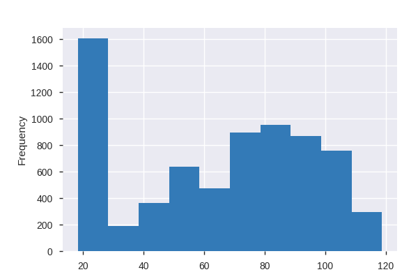

**Common Values**

| Value | Count | Frequency (%) |  |
| --- | --- | --- | --- |
| 20.05 | 61 | 0.9% |  |
| 19.85 | 45 | 0.6% |  |
| 19.95 | 44 | 0.6% |  |
| 19.9 | 44 | 0.6% |  |
| 20.0 | 43 | 0.6% |  |
| 19.7 | 43 | 0.6% |  |
| 19.65 | 43 | 0.6% |  |
| 19.55 | 40 | 0.6% |  |
| 20.15 | 40 | 0.6% |  |
| 19.75 | 39 | 0.6% |  |
| Other values (1575) | 6601 | 93.7% |  |

**Extreme Values**

Minimum 5 values

| Value | Count | Frequency (%) |  |
| --- | --- | --- | --- |
| 18.25 | 1 | 0.0% |  |
| 18.4 | 1 | 0.0% |  |
| 18.55 | 1 | 0.0% |  |
| 18.7 | 2 | 0.0% |  |
| 18.75 | 1 | 0.0% |  |

Maximum 5 values

| Value | Count | Frequency (%) |  |
| --- | --- | --- | --- |
| 118.2 | 1 | 0.0% |  |
| 118.35 | 1 | 0.0% |  |
| 118.6 | 2 | 0.0% |  |
| 118.65 | 1 | 0.0% |  |
| 118.75 | 1 | 0.0% |  |

TotalCharges  
Categorical

| Distinct count | 6531 |
| --- | --- |
| Unique (%) | 92.7% |
| Missing (%) | 0.0% |
| Missing (n) | 0 |

| 20.2 | 11 |
| --- | --- |
|  | 11 |
| 19.75 | 9 |
| Other values (6528) | 7012 |

Toggle details

| Value | Count | Frequency (%) |  |
| --- | --- | --- | --- |
| 20.2 | 11 | 0.2% |  |
|  | 11 | 0.2% |  |
| 19.75 | 9 | 0.1% |  |
| 19.65 | 8 | 0.1% |  |
| 19.9 | 8 | 0.1% |  |
| 20.05 | 8 | 0.1% |  |
| 19.55 | 7 | 0.1% |  |
| 45.3 | 7 | 0.1% |  |
| 20.15 | 6 | 0.1% |  |
| 20.25 | 6 | 0.1% |  |
| Other values (6521) | 6962 | 98.8% |  |

Churn  
Categorical

| Distinct count | 2 |
| --- | --- |
| Unique (%) | 0.0% |
| Missing (%) | 0.0% |
| Missing (n) | 0 |

| No | 5174 |
| --- | --- |
| Yes | 1869 |

Toggle details

| Value | Count | Frequency (%) |  |
| --- | --- | --- | --- |
| No | 5174 | 73.5% |  |
| Yes | 1869 | 26.5% |  |

Correlations

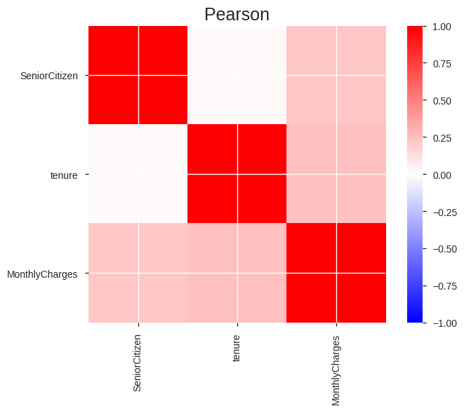

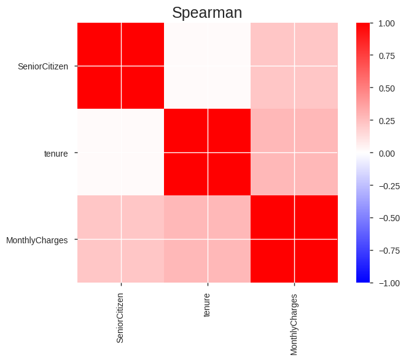

Sample

|  | customerID | gender | SeniorCitizen | Partner | Dependents | tenure | PhoneService | MultipleLines | InternetService | OnlineSecurity | OnlineBackup | DeviceProtection | TechSupport | StreamingTV | StreamingMovies | Contract | PaperlessBilling | PaymentMethod | MonthlyCharges | TotalCharges | Churn |
| --- | --- | --- | --- | --- | --- | --- | --- | --- | --- | --- | --- | --- | --- | --- | --- | --- | --- | --- | --- | --- | --- |
| 0 | 7590-VHVEG | Female | 0 | Yes | No | 1 | No | No phone service | DSL | No | Yes | No | No | No | No | Month-to-month | Yes | Electronic check | 29.85 | 29.85 | No |
| 1 | 5575-GNVDE | Male | 0 | No | No | 34 | Yes | No | DSL | Yes | No | Yes | No | No | No | One year | No | Mailed check | 56.95 | 1889.5 | No |
| 2 | 3668-QPYBK | Male | 0 | No | No | 2 | Yes | No | DSL | Yes | Yes | No | No | No | No | Month-to-month | Yes | Mailed check | 53.85 | 108.15 | Yes |
| 3 | 7795-CFOCW | Male | 0 | No | No | 45 | No | No phone service | DSL | Yes | No | Yes | Yes | No | No | One year | No | Bank transfer (automatic) | 42.30 | 1840.75 | No |
| 4 | 9237-HQITU | Female | 0 | No | No | 2 | Yes | No | Fiber optic | No | No | No | No | No | No | Month-to-month | Yes | Electronic check | 70.70 | 151.65 | Yes |

```python
import pandas_profiling
eda_report=pandas_profiling.ProfileReport(df)
eda_report
eda_report.to_file("eda_report.html")
```

```python
from google.colab import drive
drive.mount('/content/drive')
```